### Load necessary libraries

```r
library(tidyverse)         # For data wrangling when necessary
library(ggplot2)           # For data visualization
library(broom)             # For making tidy tibles from stats objects
library(boot)              # For cross-validation analysis
library(pROC)              # For ROC curve
library(tidyr)             # For changing the shape of data
library(car)               # For VIF calculation (multicollinearity)
library(MASS)              # For stepwise model selection
library(gtsummary)         # Cleaner table of the model summary
library(ResourceSelection) # For  Hosmer–Lemeshow test
library(knitr)             # For a better formatting of tabular output
```

### Read the dataset

```r
data <- read.csv('../output/Humans_regression_data.csv') # Output of the previous step
```

### Convert categorical variables to factors and set reference categories for some variables.

All the other variables will keep their default reference categories. For example, all Yes or No variables have “No” as their ref category.

```r
data$ELISA <- ifelse(data[['ELISA']] == 'Positive', 1, 0)

# Convert categorical variables to factors
data <- data %>% mutate_if(is.character, as.factor)

# Set "livestock farmers" as the reference occupation category
data$OccupGroup <- relevel(data$OccupGroup, ref = "livestock farmers")
```

### UNIVARIABLE LOGISTIC REGRESSION FOR EACH RISK FACTOR

```r
# List of predictor variables for univariable logistic regression
predictors <- c("Sector", "Gender", "Age", "Marital_status", "Education", "OccupGroup",
                "parturition", "contact_with_waste", "aborted_fetus",
                "milking", "Herded_livestock", "Slaughtered",
                "boiled_milk", "Raw_milk")

# Outcome variable
outcome <- "ELISA"

# Function to run univariable logistic regression for a single predictor and extract OR, CIs, p-value
run_univariable_logistic <- function(predictor, data) {
  formula <- as.formula(paste(outcome, "~", predictor))
  model <- glm(formula, data = data, family = binomial)
  tidy_model <- tidy(model, conf.int = TRUE)

  # Calculate odds ratios and confidence intervals
  tidy_model <- tidy_model %>%
    mutate(odds_ratio = round(exp(estimate), 2),
           lower_ci = round(exp(conf.low), 2),
           upper_ci = round(exp(conf.high), 2),
           p.value = round(p.value, 2)) %>%
    filter(term != "(Intercept)")  # Exclude the intercept

  # Extract the variable name (e.g., "Male" instead of "GenderMale")
  tidy_model <- tidy_model %>%
    mutate(term = str_replace(term, paste0(predictor), ""))  # Remove predictor from term


  # Add reference category (first category in each group)
  reference_category <- data %>%
    select(!!sym(predictor)) %>%
    distinct() %>%
    arrange(!!sym(predictor)) %>%
    slice(1) %>%
    pull(!!sym(predictor))

  # Create reference row with dashes and convert all columns to character
  reference_row <- data.frame(term = reference_category,
                              odds_ratio = "-",
                              lower_ci = "-",
                              upper_ci = "-",
                              p.value = "-",
                              predictor = predictor,
                              stringsAsFactors = FALSE)

  # Convert all columns in tidy_model to character before combining
  tidy_model <- tidy_model %>%
    mutate(odds_ratio = as.character(odds_ratio),
           lower_ci = as.character(lower_ci),
           upper_ci = as.character(upper_ci),
           p.value = as.character(p.value))

  # Combine reference category with the model results
    tidy_model <- bind_rows(reference_row, tidy_model)

  # Select relevant columns: odds ratios, confidence intervals, and p-values
   tidy_model <- tidy_model %>%
    select(predictor, term, odds_ratio, lower_ci, upper_ci, p.value)

    #  tidy_model <- tidy_model %>%
    # select(term, odds_ratio, lower_ci, upper_ci, p.value) %>%
    # mutate(predictor = predictor)  # Add the predictor name to the result

  return(tidy_model)
}
```

```r
# Run univariable logistic regression for each predictor and store results in a list
results_list <- lapply(predictors, run_univariable_logistic, data = data)

# Combine all results into a single data frame
univariable_results <- bind_rows(results_list)

# Replace NA values in the Predictor column with empty strings
univariable_results <- univariable_results %>%
  replace_na(list(predictor = ""))

# Rename the columns for better presentation
univariable_results <- univariable_results %>%
  rename(`Predictor` = predictor,
         `Variable` = term,
         `Odds Ratio` = odds_ratio,
         `Lower 95% CI` = lower_ci,
         `Upper 95% CI` = upper_ci,
         `P-value` = p.value)

# Print the univariable logistic regression results

kable(univariable_results,
      col.names = c("Risk factor", "Category", "Odds Ratio", "Lower 95% CI", "Upper 95% CI", "P-value"),
      caption = "Univariable Logistic Regression Results",
      format = "markdown")
```

Univariable Logistic Regression Results

| Risk factor | Category | Odds Ratio | Lower 95% CI | Upper 95% CI | P-value |
| --- | --- | --- | --- | --- | --- |
| Sector | Karangazi | - | - | - | - |
|  | Rwempasha | 0.82 | 0.54 | 1.26 | 0.36 |
|  | Rwimiyaga | 0.94 | 0.63 | 1.43 | 0.79 |
| Gender | Female | - | - | - | - |
|  | Male | 2.77 | 1.76 | 4.57 | 0 |
| Age | 18-25 | - | - | - | - |
|  | 26-35 | 1.46 | 0.82 | 2.65 | 0.21 |
|  | 36-45 | 2.42 | 1.36 | 4.45 | 0 |
|  | 46-55 | 3.91 | 2.18 | 7.24 | 0 |
|  | Over 55 | 5.42 | 2.94 | 10.28 | 0 |
| Marital_status | Divorced/Separated | - | - | - | - |
|  | Married | 644868.14 | 0 | NA | 0.98 |
|  | Single | 350038.22 | 0 | NA | 0.98 |
|  | Widow | 222966.32 | 4.46174710670208e+66 | 5.26637203982011e+95 | 0.98 |
| Education | College (University) | - | - | - | - |
|  | High school | 0.5 | 0.25 | 0.99 | 0.05 |
|  | Middle school | 0.36 | 0.16 | 0.78 | 0.01 |
|  | Never went to school | 0.91 | 0.5 | 1.69 | 0.75 |
|  | Primary school | 0.54 | 0.31 | 0.97 | 0.03 |
| OccupGroup | livestock farmers | - | - | - | - |
|  | Animal health care practitioner | 1.76 | 0.95 | 3.18 | 0.06 |
|  | Human health care practitioner | 0.78 | 0.31 | 1.75 | 0.58 |
|  | meat handlers | 0.35 | 0.19 | 0.61 | 0 |
|  | milk handlers | 0.62 | 0.39 | 0.97 | 0.04 |
|  | others | 0.81 | 0.18 | 2.62 | 0.75 |
| parturition | No | - | - | - | - |
|  | Yes | 0 | NA | 7.8378785926359e+36 | 0.98 |
|  | Yes | 2.09 | 1.4 | 3.09 | 0 |
| contact_with_waste | No | - | - | - | - |
|  | Yes | 2.46 | 1.76 | 3.45 | 0 |
| aborted_fetus | No | - | - | - | - |
|  | Yes | 3.32 | 2.28 | 4.84 | 0 |
| milking | No | - | - | - | - |
|  | Yes | 2.38 | 1.7 | 3.35 | 0 |
| Herded_livestock | No | - | - | - | - |
|  | Yes | 2.29 | 1.62 | 3.23 | 0 |
| Slaughtered | No | - | - | - | - |
|  | Yes | 0.51 | 0.3 | 0.82 | 0.01 |
| boiled_milk | No | - | - | - | - |
|  | Yes | 0.96 | 0.69 | 1.33 | 0.79 |
| Raw_milk | No | - | - | - | - |
|  | Yes | 1.16 | 0.84 | 1.62 | 0.37 |

```r
# Save results to a CSV file
write.csv(univariable_results, "../output/humans_univariable_logistic.csv", row.names = FALSE)
```

### FITTING A MULTIPLE LOGISTIC REGRESSION

#### Step 1: Fit the full logistic regression model with all predictors

```r
set.seed(123)
full_model <- glm(ELISA ~ Gender + Age + Marital_status + Education + OccupGroup +
                    parturition + contact_with_waste + aborted_fetus + milking +
                    Herded_livestock + Slaughtered + boiled_milk + Raw_milk,
                  data = data, family = binomial())
```

#### Step 2: Check for multicollinearity using VIF

This step was run by curiosity. The following step should be enough to take care of predictors with multicollineality. This is because predictive accuracy of the model is more important to us than it interpretability.

```r
vif_values <- vif(full_model)
print(vif_values)  # Print VIF values
```

```
##                         GVIF Df GVIF^(1/(2*Df))
## Gender              1.262008  1        1.123391
## Age                 3.243992  4        1.158470
## Marital_status      2.347586  3        1.152843
## Education           2.677321  4        1.131000
## OccupGroup         14.071174  5        1.302666
## parturition         1.711013  2        1.143703
## contact_with_waste  2.265831  1        1.505268
## aborted_fetus       2.013722  1        1.419057
## milking             2.241319  1        1.497104
## Herded_livestock    1.857554  1        1.362921
## Slaughtered         3.212484  1        1.792340
## boiled_milk         1.627596  1        1.275773
## Raw_milk            1.910941  1        1.382368
```

Despite a VIF of 14.07 for the OccupGroup variable, it was retained in the model due to its importance in the overall predictive performance, as verified by stepwise regression based on the Akaike Information Criterion (AIC). Stepwise model selection (see below) was conducted to reduce the number of predictors and identify the most parsimonious model.

#### Step 3: Perform stepwise model selection using AIC to reduce variables

```r
step_model <- step(full_model, direction = "backward")
```

#### Step 4: Evaluate the goodness of fit

####Step 4.1: Cross-validation to evaluate model performance

```r
cv_model <- cv.glm(data, step_model, K = 10)
print(cv_model$delta)  # Print cross-validated error (lower is better)
```

```
## [1] 0.1437119 0.1434163
```

####Step 4.2: ROC curve to assess the model’s goodness of fit

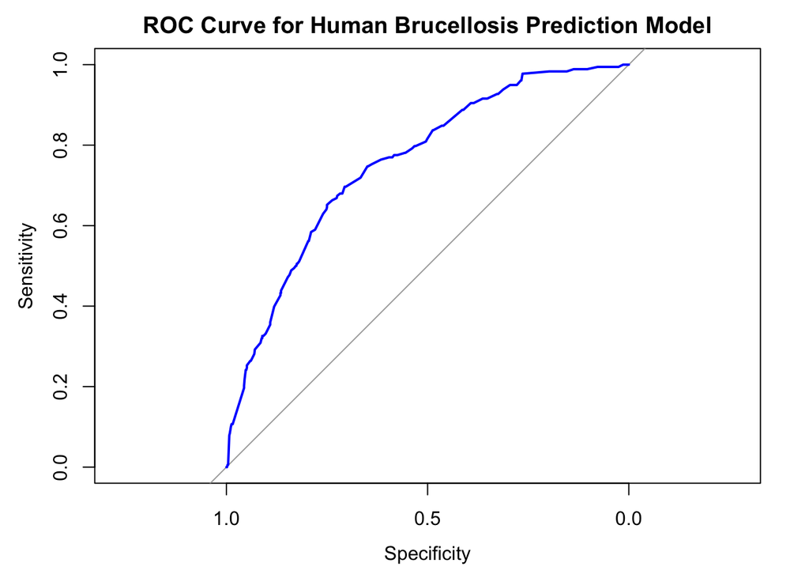

```r
pred <- predict(step_model, type = "response")
roc_curve <- roc(data$ELISA, pred)
plot(roc_curve, main = "ROC Curve for Human Brucellosis Prediction Model", col = "blue")
```

```r
auc_value <- auc(roc_curve)
print(paste("AUC:", auc_value))
```

```
## [1] "AUC: 0.756304354726084"
```

#### Hosmer–Lemeshow test

Hosmer–Lemeshow test run by curiosity but will not report it due to its documented limitations and problems. Cross-validation and ROC curve are prefered and enough for assessing the model performance and generalizability.

```r
gf <- hoslem.test(data$ELISA, fitted(step_model), g = 10)
print(gf)
```

```
##
##  Hosmer and Lemeshow goodness of fit (GOF) test
##
## data:  data$ELISA, fitted(step_model)
## X-squared = 9.8111, df = 8, p-value = 0.2785
```

#### Step 5: Extract the significant risk factors and convert to odds ratios

```r
tidy_model <- tidy(step_model, conf.int = TRUE)
significant_terms <- tidy_model %>%
  filter(p.value < 0.05) %>%
  select(term, estimate, conf.low, conf.high, p.value) %>%
  mutate(odds_ratio = exp(estimate),
         lower_ci = exp(conf.low),
         upper_ci = exp(conf.high))

print(significant_terms)
```

```
## # A tibble: 6 × 8
##   term         estimate conf.low conf.high  p.value odds_ratio lower_ci upper_ci
##   <chr>           <dbl>    <dbl>     <dbl>    <dbl>      <dbl>    <dbl>    <dbl>
## 1 (Intercept)    -3.75    -4.55      -3.01 9.14e-22     0.0234   0.0105   0.0491
## 2 GenderMale      0.977    0.453      1.54 3.83e- 4     2.66     1.57     4.64
## 3 Age36-45        1.06     0.447      1.70 8.74e- 4     2.88     1.56     5.47
## 4 Age46-55        1.59     0.964      2.24 1.02e- 6     4.89     2.62     9.41
## 5 AgeOver 55      2.00     1.34       2.69 6.07e- 9     7.39     3.82    14.8
## 6 OccupGroupA…    1.07     0.319      1.80 4.66e- 3     2.90     1.38     6.06
```

#### Step 6: Write model results to table

```r
# Display summary of the best model from stepwise regression
# summary(step_model)

tbl_regression(step_model, exponentiate = TRUE)
```

| **Characteristic** | **OR**<sup>1</sup> | **95% CI**<sup>1</sup> | **p-value** |
| --- | --- | --- | --- |
| Gender |  |  |  |
| Female | — | — |  |
| Male | 2.66 | 1.57, 4.64 | <0.001 |
| Age |  |  |  |
| 18-25 | — | — |  |
| 26-35 | 1.55 | 0.85, 2.91 | 0.2 |
| 36-45 | 2.88 | 1.56, 5.47 | <0.001 |
| 46-55 | 4.89 | 2.62, 9.41 | <0.001 |
| Over 55 | 7.39 | 3.82, 14.8 | <0.001 |
| OccupGroup |  |  |  |
| livestock farmers | — | — |  |
| Animal health care practitioner | 2.90 | 1.38, 6.06 | 0.005 |
| Human health care practitioner | 2.36 | 0.84, 6.00 | 0.083 |
| meat handlers | 0.73 | 0.35, 1.48 | 0.4 |
| milk handlers | 1.09 | 0.64, 1.84 | 0.8 |
| others | 3.99 | 0.79, 15.6 | 0.062 |
| contact_with_waste |  |  |  |
| No | — | — |  |
| Yes | 1.60 | 0.97, 2.64 | 0.065 |
| aborted_fetus |  |  |  |
| No | — | — |  |
| Yes | 1.57 | 0.94, 2.64 | 0.085 |
| milking |  |  |  |
| No | — | — |  |
| Yes | 1.57 | 0.94, 2.64 | 0.088 |

<sup>1</sup> OR = Odds Ratio, CI = Confidence Interval

```r
# Function to calculate odds ratios, confidence intervals, and p-values
calculate_results <- function(model) {
  results <- tidy(model, conf.int = TRUE) %>%
    mutate(odds_ratio = exp(estimate),
           lower_ci = exp(conf.low),
           upper_ci = exp(conf.high),
           p.value = p.value,  # Do not round p-values
           odds_ratio = round(odds_ratio, 2),
           lower_ci = round(lower_ci, 2),
           upper_ci = round(upper_ci, 2)) %>%
    select(term, odds_ratio, lower_ci, upper_ci, p.value) %>%
  return(results)
}
```

```r
# Use broom::tidy to get coefficients from the best model

tidy_model <- calculate_results(step_model)

# Add a column to distinguish between significant and non-significant factors
# p-value < 0.05 is considered significant
tidy_model <- tidy_model %>%
  mutate(significance = ifelse(p.value < 0.05, "Significant", "Non-significant"))

# Modify the variable name to include a colon to separate variables and categories
tidy_model <- tidy_model %>%
  mutate(term = case_when(
    str_detect(term, "Gender") ~ str_replace(term, "Gender", "Gender: "),
    str_detect(term, "Age") ~ str_replace(term, "Age", "Age: "),
    str_detect(term, "Education") ~ str_replace(term, "Education", "Education: "),
    str_detect(term, "OccupGroup") ~ str_replace(term, "OccupGroup", "OccupGroup: "),
    str_detect(term, "contact_with_waste") ~ str_replace(term, "contact_with_waste", "Contact with waste: "),
    str_detect(term, "aborted_fetus") ~ str_replace(term, "aborted_fetus", "Handled aborted fetus: "),
    str_detect(term, "milking") ~ str_replace(term, "milking", "Milking: "),
    str_detect(term, "Herded_livestock") ~ str_replace(term, "Herded_livestock", "Herded livestock: ")
  )) %>%drop_na()

# Write to table
out_table <- tidy_model %>% select(c("term", "odds_ratio", "lower_ci", "upper_ci", "p.value"))
write.csv(out_table, "../output/Humans_multivariable_results_with_ci.csv", row.names = FALSE)
```

### Step 7: Plot the odds ratios for all risk factors and color significant ones differently

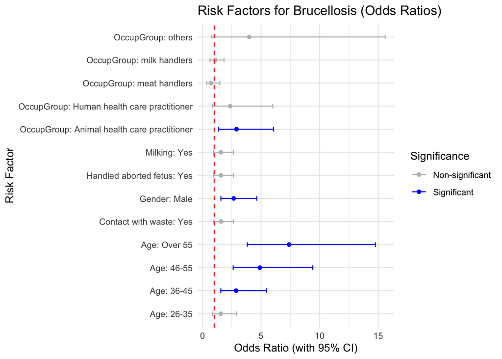

```r
tidy_model %>%
  ggplot(aes(x = term, y = odds_ratio, color = significance)) +
  geom_point() +
  geom_errorbar(aes(ymin = lower_ci, ymax = upper_ci), width = 0.2) +
  geom_hline(yintercept = 1, linetype = "dashed", color = "red") +  # Reference line at OR = 1
  coord_flip() +
  scale_color_manual(values = c("Significant" = "blue", "Non-significant" = "gray")) +  # Custom colors
  labs(title = "Risk Factors for Brucellosis (Odds Ratios)",
       x = "Risk Factor",
       y = "Odds Ratio (with 95% CI)",
       color = "Significance") +
  theme_minimal()
```